# raport

Piechocka Deka Kornel

2023-06-12

## Projekt 2

### Wstęp

Stworzony przez nasz dashboard służy do polecenia użytkownikowi filmów oraz seriali z serwisu Netflix na podstawie jego preferencji. Dane wykorzystane do projektu można znaleźć pod linkami:

https://www.kaggle.com/datasets/victorsoeiro/netflix-tv-shows-and-movies?select=titles.csv

https://www.kaggle.com/datasets/shivamb/netflix-shows

### Zakładka 1

Pierwsza zakładka zawiera panel boczny, na którym możemy wybrać konkretne cechy, jakie chcemy aby zarekomendowany nam film posiadał. Cechy takie jak rodzaj (film, czy serial), gatunek, kraj i rok produkcji oraz ocena innych użytkowników. Po wybraniu konkretnych własności, aplikacja zwraca na panelu głównym wykresy przedstawiające długość trwania, bądź oceny filmów lub seriali, spełniających kryteria przez nas wprowadzone.

[figure not shown]

### Zakładka 2

Druga zakładka zawiera tabelę, w której możemy znaleźć dodatkowe informacje na temat interesujacych nas filmów. Wpisujac w oknie wyszukiwania tytuł będziemy mogli przeczytać krótki opis filmu oraz dowiedzieć się, w którym roku powstał i jaką ma ocenę. Jeżeli chcemy znależć film, w którym pojawia się konkretny motyw, także możemy go wyszukać wpisując słowo klucz. Otrzymane wyniki można dodatkowo posortować względem ocen lub roku powstania.

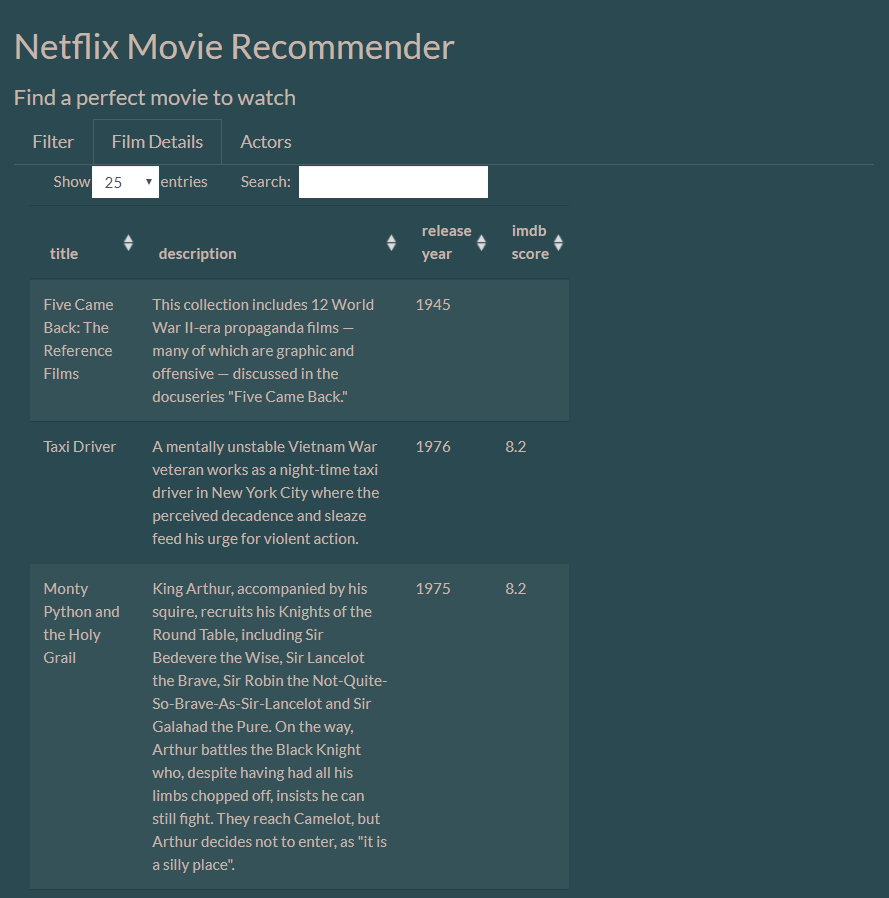

### Zakładka 3

W trzeciej zakładce możemy wybrać aktora, z udziałem, którego filmy chcemy przejrzeć (oczywiście wyświetlą się tylko filmy dostępne na netflix). Na wykresie wyświetlają się oceny poszczególnych filmów, a pod wykresem możemy sprawdzić szczegóły dotyczące tych filmów takie jak opis, aktorzy czy rok wydania.

[figure not shown]